# Best Sports club in the world - Case Study

(Note: Name confidential)

## Questions solved

*1. Where do customers come from? Which sites/ads are “feeding” our sales?*

Considering websites, total sales come from:  
• 69% organic (search engines, 64% google, 2% bing, 1% yahoo, 1% navers, 1% others)  
• 26% direct  
• 5% others  
Regarding geography, sales come from:  
• 71% Spain  
• 5% UK  
• 3% France  
• 3% Germany and Switz.  
• 2% USA  
• 16% others  
*2. Which combinations of sources and mediums attract the more amount of new visitors?*  
• 54% organic (search engines, 51% google, 1% bing, 1% yahoo, 0,5% navers, 0,5% others)  
• 36% direct  
• 3% t.co, referral (twitter)  
• 2% m.facebook.com and facebook.com, referral  
• 4% others  
*3. Is there a correlation between the time a page takes to load and sales? (Are we loosing clients because the site doesn’t load?)*  
• In a first analysis it seems that there is a 0.67 correlation between Transactions and Loading time  
• However, when one builds a linear regression on the most significant variables (significance level=5%)  
• Linear regression shows 0 coefficient for load time and a relatively small coefficient for ln(Load time), but 1 order of magnitude lower than the others  
*4. Are people who initially came from banners more likely to buy or not?*  
• Users that landed on the website coming from banners have zero purchases  
*5. Can we build a model to predict average purchase?*  
• No, a regression for this would yield R2=8% but the regressions for quantity or total revenues yield R2=99%

## Questions to solve

*6. Adding to the question 1 of where do customer come from: do users in (club's home city) buy online? Is a significant share of the buyers from (club's home city)? Otherwise we can raise the question if the (locals) know that they can buy online…*

*7. How do new users find the website? How could the club further spread the brand and increase the number of new users to the website?*  
*8. Are ticket buyers already regular visitors to the site? Or are they mostly coming for one time purchase?*  
*9. What is the average time spent on the website? What do users do on it?*  
*10. Are users accessing from certain brands of computers/smartphones more likely to buy? Or to have a higher Order Average Value?*

*11. Could we find a way to better segment the market of buyers online?*  
*12. What are the pages with the highest average time on page? Should we suggest to have more of this content? And do these views lead to sales?*  
*13. How could the club further spread the brand? Which dimensions/metrics could we look into to address this? Eg. What is the bounce rate vs some benchmark?*

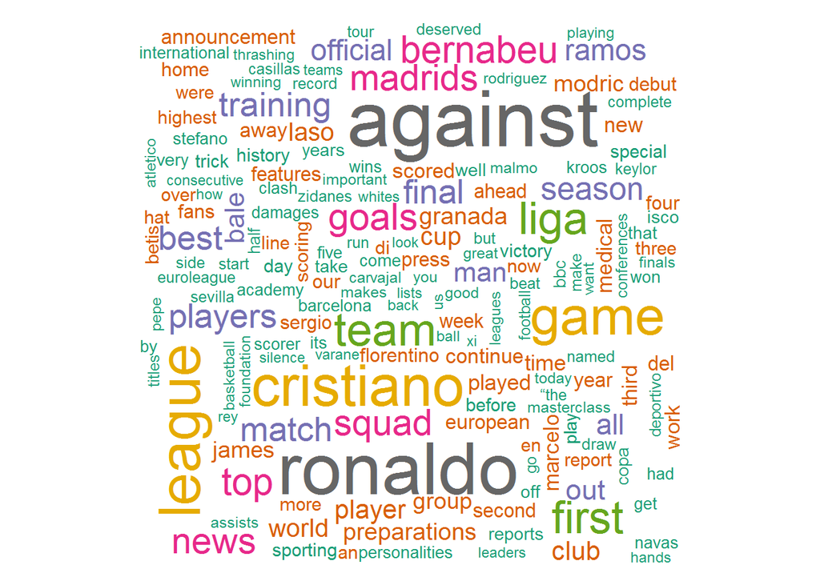

## Questions unsolvable due to lack of data

1. Are there products that are typically bought together (e.g. game tickets and sweaters)? Could we work on some bundles? - *Cannot test*
2. What are the trends in purchases before the matches? - *Cannot test*